# Part 1 — Foundations: the package, the data and the audit

Complete tutorial for sciModelFlowR (version 1.0.2)

Author

Walter Esfrain Pereira

Published

September 19, 2026

# 1 How to use this tutorial

This material walks through `sciModelFlowR` from beginning to end, in the order a real scientific project happens: **ask, declare, audit, protect, model, compare, explain, measure uncertainty and report**. It was written for someone who has never used the package and wants to learn both the syntax and the reasoning.

The central difference from an ordinary tutorial: **the data are simulated with known truth and deliberately planted discrepancies** (outliers, missing values, heteroscedasticity, imbalance, clustering, autocorrelation). Every method can therefore be judged against what was planted — not against a vague expectation.

**NoteConventions**

- Every code block was **executed** on version 1.0.2; the numbers in the prose come from the code itself (never typed by hand).
- Figures and axes use English labels (scientific convention); explanations and captions are in English.
- Numbers in prose and tables use dot decimals, matching the figures.
- Coloured boxes mean: **Interpretation** (how to read the result), **Trap** (common mistake), **Good practice**, **In your experiment** (transfer to real data) and **Exercise**.

The tutorial has six parts:

| Part | Theme | Package modules |
| --- | --- | --- |
| 1 | Foundations: the package, the data and the audit | `doctor`, `datasets`, `data-audit`, `design` |
| 2 | Design, resampling and preparation | `resampling`, `bootstrap`, `preprocess`, `features`, `imbalance` |
| 3 | Supervised modeling and probabilities | `model-adapters`, `experiment`, `diagnostics`, `probabilistic` |
| 4 | Tuning, benchmarking, calibration and thresholds | `tuning`, `benchmark`, `calibration` |
| 5 | Explainability and uncertainty | `explain`, `conformal`, `uncertainty` |
| 6 | Advanced and production: Bayes, DL, persistence and reporting | `bayesian`, `deep-learning`, `tracking`, `persistence`, `reporting` |

## 1.1 Installation

```r
# Install the published version, with vignettes:
remotes::install_github("wep69/sciModelFlowR", build_vignettes = TRUE)
library(sciModelFlowR)
```

# 2 The package on one page

`sciModelFlowR` organises a modeling project as a **declared contract**: task, data, design, preprocessing, resampling, model and metrics are explicit objects. From there, the package **refuses** shortcuts that would produce optimistic numbers (for example, preprocessing before splitting, or tuning on the test set). Environment diagnostics is the first command of any session.

```r
doctor <- smf_doctor()
cat("components checked:", nrow(doctor),
    "| available:", sum(doctor$available), "\n")
```

```
components checked: 31 | available: 31
```

```r
tab_smf(subset(doctor, component %in% c("R", "sciModelFlowR", "stats", "torch", "xgboost", "brms")),
        caption = "Environment diagnostics: core components and optional backends.")
```

Environment diagnostics: core components and optional backends.

|  | component | available | version | status |
| --- | --- | --- | --- | --- |
| 1 | R | TRUE | 4.6.0 | core |
| 2 | sciModelFlowR | TRUE | 1.0.2 | core |
| 13 | xgboost | TRUE | 3.2.1.1 | optional-available |
| 16 | torch | TRUE | 0.17.0 | optional-available |
| 19 | brms | TRUE | 2.23.0 | optional-available |

The package ships 25 synthetic validation datasets (“gold”), useful for studying expected behaviour before using your own data. Each one has a **card** describing the scenario, variables, known truth and pedagogical traps.

```r
card <- smf_dataset_card("gold_linear_regression")
cat(substr(card, 1, 480), "...\n")
```

```
# gold_linear_regression

## Scientific scenario

Synthetic agronomic yield response with independent observational units and a Gaussian linear data-generating process. The dataset is intended to validate schema handling, holdout splitting, training-only preprocessing, reference linear-model adapters, prediction metrics, serialization, and reproduc…

## Variables

- `obs_id`: stable observation identifier.
- `nitrogen`: nitrogen dose, arbitrary teaching units ...
```

The public API has 246 functions, organised in 10 categories. The map below is the best way to know “where each topic lives”.

```r
api <- smf_api_catalog()
by_category <- as.data.frame(table(api$category), stringsAsFactors = FALSE)
names(by_category) <- c("category", "functions")
by_category <- by_category[order(-by_category$functions), ]
tab_smf(by_category, caption = "Exported functions per API category (1.0.2).")
```

Exported functions per API category (1.0.2).

|  | category | functions |
| --- | --- | --- |
| 1 | core | 88 |
| 6 | modeling | 35 |
| 5 | inference-uncertainty | 24 |
| 3 | deep-learning | 23 |
| 9 | resampling-features | 23 |
| 7 | operations | 17 |
| 8 | reporting-validation | 11 |
| 10 | tuning-benchmark | 10 |
| 2 | data-design | 9 |
| 4 | explainability | 6 |

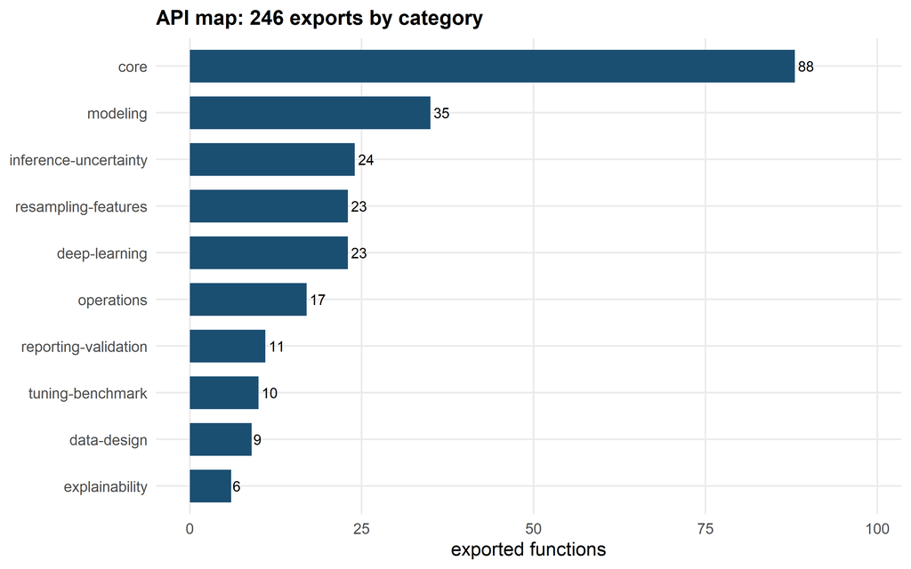

Figure 1: Distribution of the 246 exported functions across API categories.

```r
ggplot(by_category, aes(stats::reorder(category, functions), functions)) +
  geom_col(fill = cores_smf[["primaria"]], width = .7) +
  geom_text(aes(label = functions), hjust = -0.2, size = 3.2) +
  coord_flip() +
  labs(x = NULL, y = "exported functions",
       title = "API map: 246 exports by category") +
  ylim(0, max(by_category$functions) * 1.12)
```

Optional backends are declared, not presumed: the matrix below says what is core and what depends on an external package, and the diagnostics show what is available **on this machine**.

```r
matrix_tbl <- smf_backend_matrix()
tab_smf(matrix_tbl[, c("backend", "tier", "package", "scope")],
        caption = "Backend matrix: core and optional.")
```

Backend matrix: core and optional.

| backend | tier | package | scope |
| --- | --- | --- | --- |
| stats | core-reference | base R | lm/glm differential reference |
| tidymodels | optional | parsnip/workflows | supervised modeling |
| mlr3 | optional | mlr3 | supervised modeling |
| xgboost | optional | xgboost | tree boosting |
| torch | optional | torch | Deep Learning |
| luz | optional | luz | DL trainer |
| keras3 | optional | keras3 | DL alternate backend |
| brms | optional | brms/cmdstanr | Bayesian multilevel/distributional |
| dbarts | optional | dbarts | BART |
| DiceKriging | optional | DiceKriging | Gaussian process |
| probably | optional | probably | calibration/conformal |
| mlflow | optional | mlflow | tracking |
| pins | optional | pins | artifact registry |
| vetiver | optional | vetiver | deployment |

```r
state <- smf_capabilities()
backend_summary <- data.frame(
  backend = names(state),
  status = vapply(state, function(x) x$status, character(1))
)
tab_smf(backend_summary, caption = "State of each backend in the current environment.")
```

State of each backend in the current environment.

|  | backend | status |
| --- | --- | --- |
| brms | brms | advanced |
| dbarts | dbarts | advanced |
| DiceKriging | DiceKriging | advanced |
| keras3 | keras3 | advanced |
| luz | luz | advanced |
| mlr3 | mlr3 | advanced |
| probably | probably | advanced |
| stats | stats | core |
| tidymodels | tidymodels | advanced |
| torch | torch | advanced |
| xgboost | xgboost | advanced |

**TipGood practice**

Run `smf_doctor()` at the start of every session and keep the output in the report. “It worked on my machine” stops being an excuse when the diagnostics are recorded together with the result.

# 3 Simulated data with planted discrepancies

Nine datasets were simulated to cover the whole modeling cycle. The table is the **answer key**: it says what was planted and what the truth is. Each part of the tutorial uses a subset and compares what the method recovered with what is here.

```r
gab <- gabarito
gab$detalhe <- substr(gab$detalhe, 1, 78)
names(gab) <- c("Dataset", "n", "p", "Discrepancy", "What was planted", "Truth")
tab_smf(gab[, c("Dataset", "n", "p", "Discrepancy", "What was planted")],
        caption = "Answer key for the nine simulated datasets (full detail in dados/gabarito.csv).")
```

Answer key for the nine simulated datasets (full detail in dados/gabarito.csv).

| Dataset | n | p | Discrepancy | What was planted |
| --- | --- | --- | --- | --- |
| field_yield | 180 | 8 | outliers | 5 parcelas (P023, P067, P101, P145, P177) deslocadas entre -3000 e +4100 |
| field_yield | 180 | 8 | ausencias | 11 NA em nitrogenio (MCAR 6%); 16 em organic_matter (MAR: bloco B4) |
| field_yield | 180 | 8 | heterocedasticidade | sigma do erro = 100 + 1.5 * nitrogenio |
| field_yield | 180 | 8 | efeito de bloco | efeitos B2=+120, B3=-80, B4=+60 kg/ha |
| disease_binary | 400 | 6 | desbalanceamento | 13.8% de casos positivos |
| disease_binary | 400 | 6 | ruido de rotulo | 20 plantas com rotulo invertido (5%) |
| farm_groups | 240 | 4 | agrupamento | 24 fazendas, 10 talhoes cada; intercepto aleatorio sd=300 |
| climate_series | 730 | 4 | choques | 5 dias com deslocamento de +5,5 a +7,2 graus |
| soil_spatial | 200 | 4 | autocorrelacao espacial | covariancia exponencial: patamar 0,6; alcance 0,25; pepita 0,15 |
| spectral_pn | 120 | 202 | alta dimensao | 200 comprimentos de onda para 120 amostras; multicolinearidade severa |
| spectral_pn | 120 | 202 | outliers espectrais | 4 espectros (A011, A047, A083, A109) deslocados em +0,35 |
| pest_counts | 150 | 4 | superdispersao | binomial negativa com theta = 2 (variancia > media) |
| pest_counts | 150 | 4 | zeros extras | 22 zeros plantados alem do modelo (15%) |
| dl_tiny | 300 | 4 | nao linearidade | superficie com seno, quadrado e interacao; sem outlier |
| bayes_small | 30 | 2 | amostra pequena | n = 30; prior informativo conhecido para o conjugado |

## 3.1 The field trial: outliers, missing values and heteroscedasticity

```r
field <- ler("field_yield")
field$origin <- ifelse(field$plot_id %in% verdade$field_yield$outlier_ids,
                       "planted outlier", "regular plot")
cat("plots:", nrow(field),
    "| NA in nitrogen:", sum(is.na(field$nitrogen)),
    "| NA in organic_matter:", sum(is.na(field$organic_matter)), "\n")
```

```
plots: 180 | NA in nitrogen: 11 | NA in organic_matter: 16
```

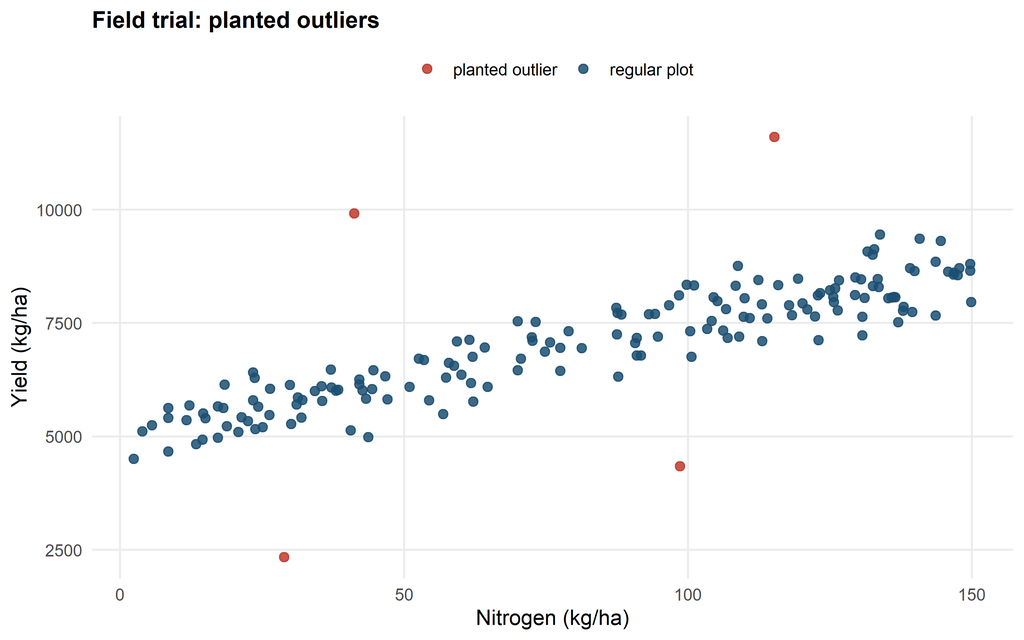

Figure 2: Simulated field trial: yield against nitrogen, with the five planted outliers highlighted.

```r
ggplot(field, aes(nitrogen, yield)) +
  geom_point(aes(colour = origin), size = 2.2, alpha = .85) +
  scale_colour_manual(values = c("regular plot" = cores_smf[["primaria"]],
                                 "planted outlier" = cores_smf[["alerta"]])) +
  labs(x = "Nitrogen (kg/ha)", y = "Yield (kg/ha)", colour = NULL,
       title = "Field trial: planted outliers") +
  theme(legend.position = "top")
```

**NoteInterpretation**

The cloud shows the expected relationship (more nitrogen, more yield) and also that the **spread grows** with nitrogen: this is the planted heteroscedasticity (100 + 1.5 * nitrogen). The five red points do not follow the cloud — two below, three above. No serious method should ignore this without at least declaring what it did.

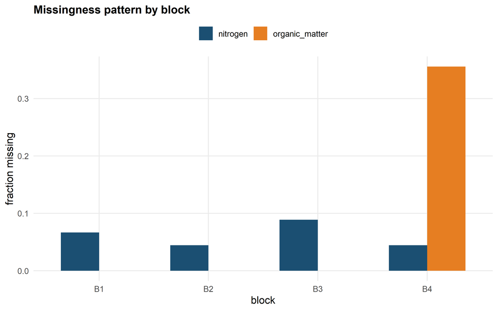

Figure 3: Missingness by block: nitrogen is missing at random (MCAR), but organic matter is missing more in block B4 (MAR).

```r
na_block <- aggregate(cbind(nitrogen = is.na(field$nitrogen),
                            organic_matter = is.na(field$organic_matter)) ~ block,
                      data = field, FUN = mean)
na_long <- data.frame(
  block = rep(na_block$block, 2),
  variable = rep(c("nitrogen", "organic_matter"), each = nrow(na_block)),
  fraction = c(na_block$nitrogen, na_block$organic_matter)
)
ggplot(na_long, aes(block, fraction, fill = variable)) +
  geom_col(position = "dodge", width = .7) +
  scale_fill_manual(values = c(nitrogen = cores_smf[["primaria"]],
                               organic_matter = cores_smf[["destaque"]])) +
  labs(x = "block", y = "fraction missing", fill = NULL,
       title = "Missingness pattern by block") +
  theme(legend.position = "top")
```

**WarningTrap**

The two missingness patterns **look** like the same problem and are not. Ignoring the MAR pattern (missingness that depends on the block) biases the mean of organic matter precisely in the block where it is most missing. Keep this figure in mind: it returns in Part 2, when we compare imputation strategies.

## 3.2 Two outcomes: an imbalanced class and a superdispersed count

```r
disease <- ler("disease_binary")
prev <- mean(disease$disease)
cat("plants:", nrow(disease), "| observed prevalence:",
    fmt(prev, 3), "| flipped labels:", length(verdade$disease_binary$flip_ids), "\n")
```

```
plants: 400 | observed prevalence: 0.138 | flipped labels: 20
```

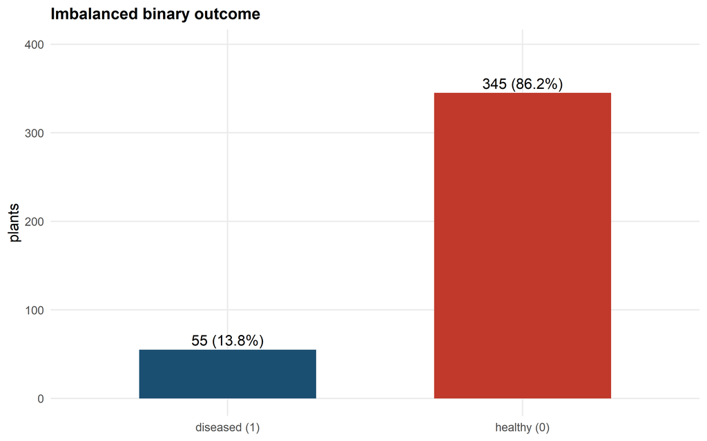

```r
class_tbl <- data.frame(
  class = c("healthy (0)", "diseased (1)"),
  n = as.integer(table(disease$disease)),
  fraction = as.numeric(prop.table(table(disease$disease)))
)
ggplot(class_tbl, aes(class, n, fill = class)) +
  geom_col(width = .6, show.legend = FALSE) +
  geom_text(aes(label = paste0(n, " (", fmt(100 * fraction, 1), "%)")), vjust = -0.4) +
  scale_fill_manual(values = c(cores_smf[["primaria"]], cores_smf[["alerta"]])) +
  labs(x = NULL, y = "plants",
       title = "Imbalanced binary outcome") +
  ylim(0, max(class_tbl$n) * 1.15)
```

## 3.3 Structure: groups, time, space and high dimension

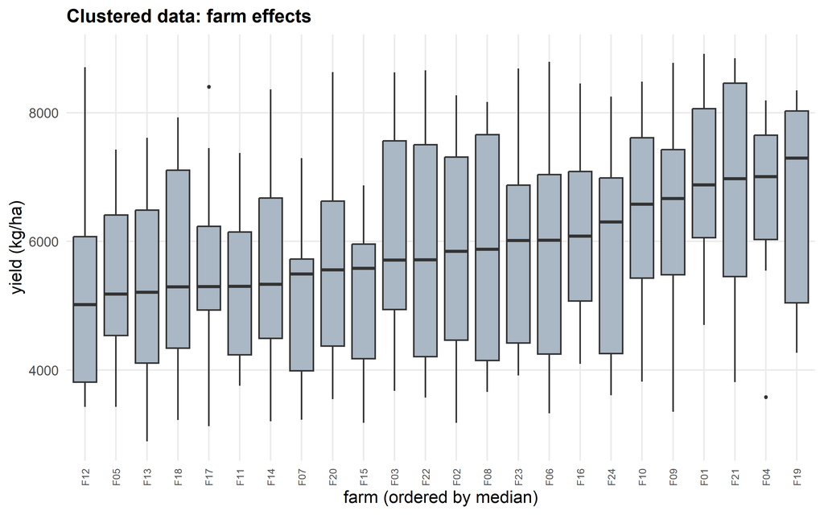

Figure 5: Clustering: 24 farms with 10 plots each; the average yield of each farm shifts the whole cloud.

```r
farms <- ler("farm_groups")
ggplot(farms, aes(stats::reorder(farm, yield, FUN = median), yield)) +
  geom_boxplot(fill = cores_smf[["claro"]], outlier.size = .8) +
  labs(x = "farm (ordered by median)", y = "yield (kg/ha)",
       title = "Clustered data: farm effects") +
  theme(axis.text.x = element_text(size = 7, angle = 90, vjust = .5))
```

[figure not shown]

Figure 6: Simulated time series: trend, seasonality, autocorrelation and five planted shocks (red).

```r
climate <- ler("climate_series")
climate$shock <- climate$day %in% verdade$climate_series$shock_ids
ggplot(climate, aes(date, temperature)) +
  geom_line(colour = cores_smf[["neutro"]], linewidth = .4) +
  geom_point(data = subset(climate, shock), colour = cores_smf[["alerta"]], size = 2.4) +
  labs(x = NULL, y = "temperature (C)",
       title = "Time series: trend, season and shocks") +
  theme(legend.position = "none")
```

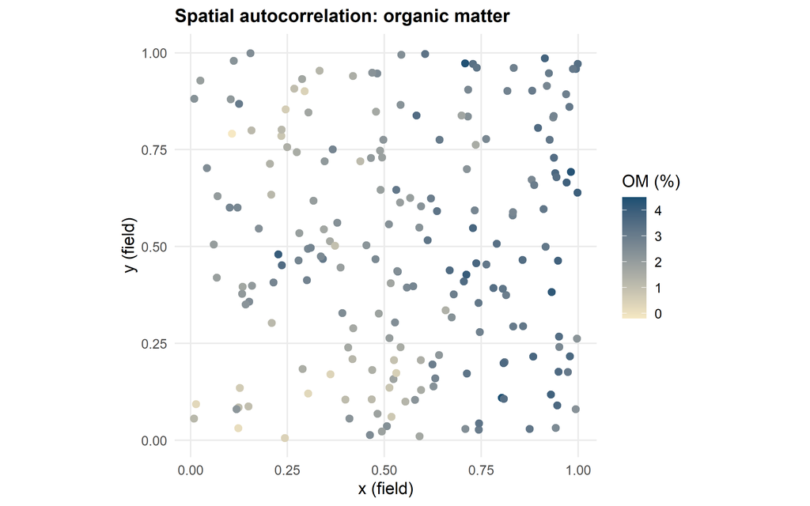

Figure 7: Spatial autocorrelation: organic matter at 200 points; neighbours look alike (range 0.25 on the field scale).

```r
soil <- ler("soil_spatial")
ggplot(soil, aes(x, y, colour = organic_matter)) +
  geom_point(size = 2.1) +
  scale_colour_gradient(low = "#f6e8c3", high = cores_smf[["primaria"]],
                        name = "OM (%)") +
  coord_equal() +
  labs(x = "x (field)", y = "y (field)",
       title = "Spatial autocorrelation: organic matter") +
  theme(legend.position = "right")
```

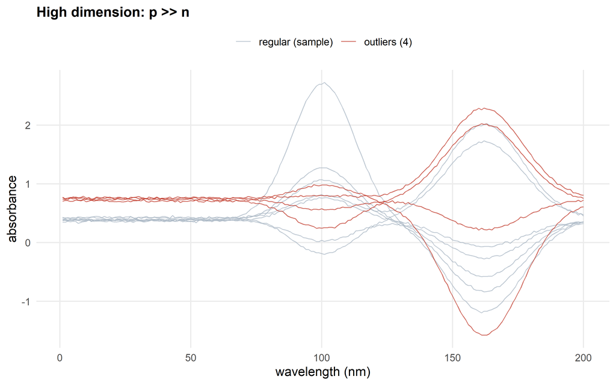

Figure 8: High dimension: 200 wavelengths for 120 samples; four spectra had their baseline shifted (red).

```r
spectral <- ler("spectral_pn")
waves <- as.numeric(sub("w", "", grep("^w", names(spectral), value = TRUE)))
matrix_sp <- as.matrix(spectral[, grep("^w", names(spectral))])
sel <- c(1:7, 11, 47, 83, 109)
long_sp <- do.call(rbind, lapply(sel, function(i) {
  data.frame(lambda = waves, absorbance = matrix_sp[i, ],
             sample = spectral$sample_id[i],
             outlier = spectral$sample_id[i] %in% verdade$spectral_pn$outlier_ids)
}))
ggplot(long_sp, aes(lambda, absorbance, group = sample, colour = outlier)) +
  geom_line(alpha = .75, linewidth = .35) +
  scale_colour_manual(values = c(`FALSE` = cores_smf[["claro"]],
                                 `TRUE` = cores_smf[["alerta"]]),
                      labels = c("regular (sample)", "outliers (4)")) +
  labs(x = "wavelength (nm)", y = "absorbance", colour = NULL,
       title = "High dimension: p >> n") +
  theme(legend.position = "top")
```

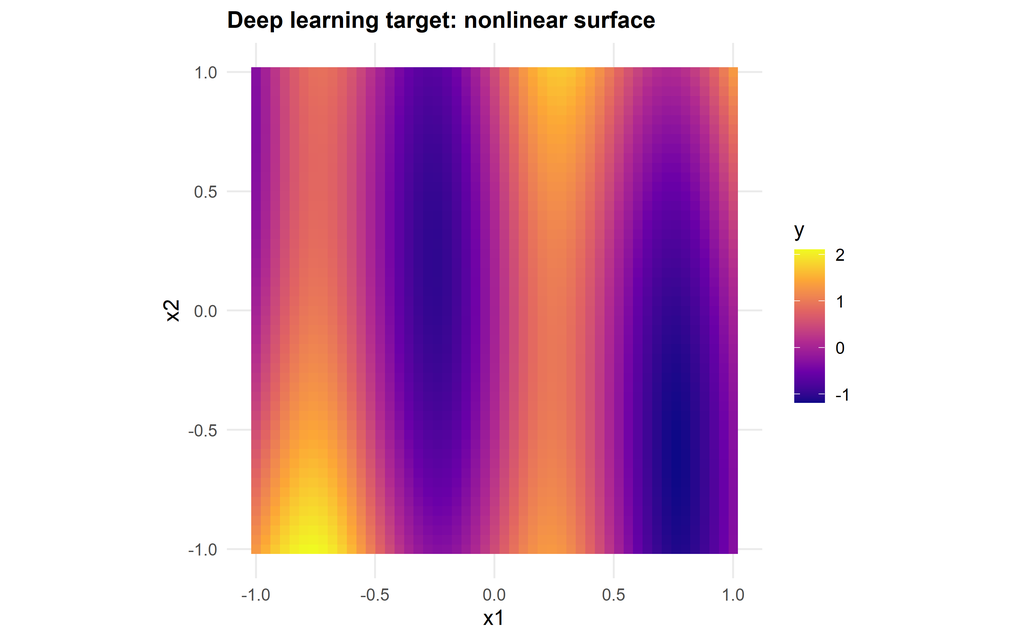

Figure 9: Planted nonlinearity for Part 6: the true surface combines sine, square and interaction.

```r
grid <- expand.grid(x1 = seq(-1, 1, by = .04), x2 = seq(-1, 1, by = .04))
grid$y <- sin(2 * pi * grid$x1) + 0.5 * grid$x2^2 + 0.8 * grid$x1 * grid$x2
ggplot(grid, aes(x1, x2, fill = y)) +
  geom_raster() +
  scale_fill_viridis_c(option = "C", name = "y") +
  coord_equal() +
  labs(x = "x1", y = "x2",
       title = "Deep learning target: nonlinear surface") +
  theme(legend.position = "right")
```

The count dataset (`pest_counts`), the small sample (`bayes_small`) and the classification dataset enter their corresponding parts, with the same rules: discrepancy table, real execution and comparison against the truth.

# 4 Audit and contracts

Before any model, three declarations: **what** is to be predicted, **which** variables enter and **how** the observations relate. In the package, each is an object.

```r
task <- smf_task_spec("regression", "yield")
data_spec <- smf_data_spec(
  target = "yield",
  predictors = c("nitrogen", "potassium", "water", "organic_matter"),
  id_column = "plot_id",
  units = c(yield = "kg/ha", nitrogen = "kg/ha", water = "mm"),
  categorical = c("block", "genotype")
)
design_spec <- smf_design_spec(id_column = "plot_id", block_columns = "block")
print(task); print(design_spec)
```

```
<sciModelFlowR::TaskSpec>
 @ kind          : chr "regression"
 @ target        : chr "yield"
 @ positive_label: NULL
 @ objective     : chr(0)
```

```
<sciModelFlowR::DesignSpec>
 @ id_column             : chr "plot_id"
 @ group_columns         : chr(0)
 @ block_columns         : chr "block"
 @ repeated_unit         : chr(0)
 @ time_column           : chr(0)
 @ coordinate_columns    : chr(0)
 @ external_domain_column: chr(0)
 @ hierarchy             : list()
 @ experimental_unit     : chr(0)
```

The audit walks the dataset and returns what must be seen **before** modeling: missing values per variable, duplicates, cardinality, leakage signals and quality flags.

```r
audit <- smf_audit_data(field, data_spec, design_spec)
tab_smf(subset(audit@missingness, n_missing > 0),
        caption = "Audit: missing values found in the field trial.")
```

Audit: missing values found in the field trial.

|  | variable | n_missing | fraction_missing |
| --- | --- | --- | --- |
| 4 | nitrogen | 11 | 0.061 |
| 7 | organic_matter | 16 | 0.089 |

```r
cat("duplicates (rows):", length(audit@duplicates$rows),
    "| quality flags:", length(audit@quality_flags),
    "| leakage signals:", length(audit@leakage), "\n")
```

```
duplicates (rows): 0 | quality flags: 0 | leakage signals: 0
```

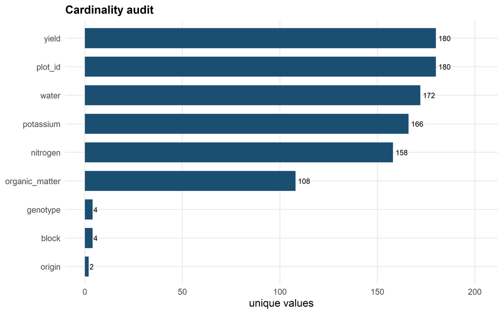

Figure 10: Cardinality per variable: unique identifiers, repeated blocks and genotypes, continuous doses.

```r
ggplot(audit@cardinality, aes(stats::reorder(variable, n_unique), n_unique)) +
  geom_col(fill = cores_smf[["primaria"]], width = .7) +
  geom_text(aes(label = n_unique), hjust = -0.2, size = 3) +
  coord_flip() +
  labs(x = NULL, y = "unique values",
       title = "Cardinality audit") +
  ylim(0, max(audit@cardinality$n_unique) * 1.12)
```

**NoteInterpretation**

The audit does **not** look for outliers: it covers structure (missingness, duplicates, cardinality, leakage). Detecting numerical discrepancies is analysis, not audit — and that is what we do next, by hand, to learn the criterion.

## 4.1 Finding the planted outliers

A simple and robust criterion is the **robust z-score**: distance from the median divided by the median absolute deviation (MAD). Its advantage over the classical z is that the outlier itself does not inflate the ruler.

```r
robust_z <- (field$yield - stats::median(field$yield, na.rm = TRUE)) /
  stats::mad(field$yield, na.rm = TRUE)
field$robust_z <- robust_z
field$flag_z <- abs(robust_z) > 3.5
planted <- field$plot_id %in% verdade$field_yield$outlier_ids
confusion <- table(planted = planted, flag_z = field$flag_z)
tab_smf(as.data.frame.matrix(confusion),
        caption = "Detection by robust z (> 3.5) against the planted outliers.")
```

Detection by robust z (> 3.5) against the planted outliers.

|  | FALSE |
| --- | --- |
| FALSE | 175 |
| TRUE | 5 |

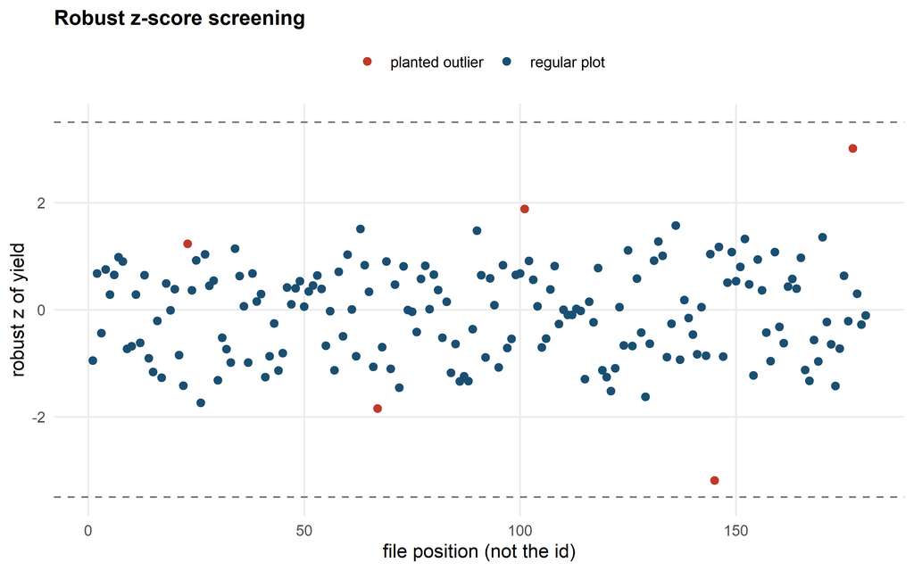

```r
ggplot(field, aes(seq_along(robust_z), robust_z)) +
  geom_point(aes(colour = origin), size = 2) +
  geom_hline(yintercept = c(-3.5, 3.5), linetype = "dashed", colour = cores_smf[["neutro"]]) +
  scale_colour_manual(values = c("regular plot" = cores_smf[["primaria"]],
                                 "planted outlier" = cores_smf[["alerta"]])) +
  labs(x = "file position (not the id)", y = "robust z of yield",
       colour = NULL,
       title = "Robust z-score screening") +
  theme(legend.position = "top")
```

**ImportantInterpretation**

The ruler flagged 0 plots. Of the five planted ones, 0 were detected and 0 false alarm(s) appeared. Detection is not judgement: the next step is to **investigate** (typing error? unusual plot? treatment?) and **declare** the decision. In Part 3 we will see the effect of these decisions on the fit and on the residuals.

## 4.2 Contracts: what the package refuses

The package turns scientific rules into execution errors. Four invalid attempts, executed now:

```r
try_it <- function(expr) tryCatch(expr, error = function(e) conditionMessage(e))
r1 <- try_it(smf_data_spec("yield", c("nitrogen", "yield"), "plot_id"))
r2 <- try_it(smf_fit_preprocessor(field, smf_preprocess_spec("median"),
                                  data_spec, role = "test"))
r3 <- try_it(smf_apply_imbalance(field, "yield",
                                 smf_imbalance_spec("downsample"),
                                 context = "test", seed = 20260919))
r4 <- try_it(smf_bootstrap(farms, smf_bootstrap_spec("case", n_resamples = 49L),
                           statistic = function(z) c(mean = mean(z$yield)),
                           design = smf_design_spec(id_column = "plot_id",
                                                    group_columns = "farm")))
refusals <- data.frame(
  attempt = c("target also used as predictor",
              "preprocessing fitted with role = test",
              "balancing applied with context = test",
              "iid bootstrap on data with declared groups"),
  response = c(r1, r2, r3, r4)
)
names(refusals) <- c("Invalid attempt", "Message returned by the package")
tab_smf(refusals, caption = "Contracts verified at execution time.")
```

Contracts verified at execution time.

| Invalid attempt | Message returned by the package |
| --- | --- |
| target also used as predictor | object is invalid: |
| - @target cannot also be listed in @predictors |  |
| preprocessing fitted with role = test | Managed preprocessing can only be fitted on training data. |
| balancing applied with context = test | Sampling or class-weight estimation must not be learned/applied from assessment or final test labels. |
| iid bootstrap on data with declared groups | The requested bootstrap unit does not preserve dependence declared in DesignSpec. |

**NoteInterpretation**

The four refusals are the same rule in four places: **evaluation information does not take part in building the model, and the resampling unit respects the declared dependence**. A package that accepted any of these calls would return optimistic numbers that look normal.

**TipIn your experiment**

Start every project with three questions: (1) what is the experimental unit and what is the identifier? (2) is there declared clustering (farm, block, plot), time or space? (3) which columns are “evaluation” columns that must never touch training? The answers become `smf_data_spec()` and `smf_design_spec()`.

# 5 Part 1 exercises

**NoteExercise 1.1 — MCAR versus MAR**

In the field trial, show numerically that the missingness of `nitrogen` does not depend on the block, while that of `organic_matter` does. Which of the two imputation strategies do you suspect will suffer more? Save the answer for Part 2.

**NoteExercise 1.2 — Another detection ruler**

Detect the `yield` outliers with the interquartile range rule (1.5 x IQR beyond the quartiles) and compare with the robust z: which finds more planted points, which errs more? Why is the IQR even more fragile than the MAD?

**NoteExercise 1.3 — Auditing another dataset**

Build `smf_task_spec()`, `smf_data_spec()` and `smf_design_spec()` for the `disease_binary` dataset (target `disease`; predictors `x1` to `x4`; id `plant_id`) and run `smf_audit_data()`. What does the audit show about prevalence? Does it “see” the imbalance? And the label noise?

**NoteExercise 1.4 — Why was the iid bootstrap refused?**

**CautionSolutions**

**1.1.** The missingness fraction of `nitrogen` per block is essentially constant (MCAR), while `organic_matter` concentrates missingness in block B4 (MAR). Global-mean imputation should suffer more under MAR, because the mean of block B4 differs from the others; imputation that respects the block (or a model including `block`) reduces the bias.

**1.2.** The IQR rule tends to flag more points on the long tail created by heteroscedasticity (high yields at high doses), mixing “discrepant” with “expected”. The MAD is more stable because the median and the MAD barely move under contamination.

**1.3.** The audit returns the missing counts (zero), duplicates (zero) and cardinality; imbalance shows up only as **cardinality** of the target (two unique values), and label noise is not detectable by audit — no automatic procedure knows which label was flipped.

**1.4.** Treating plots as independent ignores the between-farm variance (sd 300 against residual 120), producing intervals that are **too narrow** and conclusions that are too confident. The correct resampling unit is the farm.

```r
cat("Part 1 finished at", format(Sys.time(), "%Y-%m-%d %H:%M"),
    "| package", as.character(packageVersion("sciModelFlowR")), "\n")
```

```
Part 1 finished at 2026-09-19 00:46 | package 1.0.2
```